# Praca domowa 2

Ryszard Czarnecki

## Dane

Dane wykorzystane w Pracy domowej 2 opisują wycenę nieruchmości. Każda obserwacja jest pewną nieruchmością, która posiada informacje takie jak powierzchnia, liczba pokoi, liczba łazienek i wiele więcj. Opis wszystkich kolumn w pliku `README.md`.

## Zadanie 1

Jak wygląda rozkład ceny nieruchomości w poszczególnych kodach pocztowych na przestrzeni lat? Rozważamy kody pocztowe, które mają więcej niż 280 posiadłości.

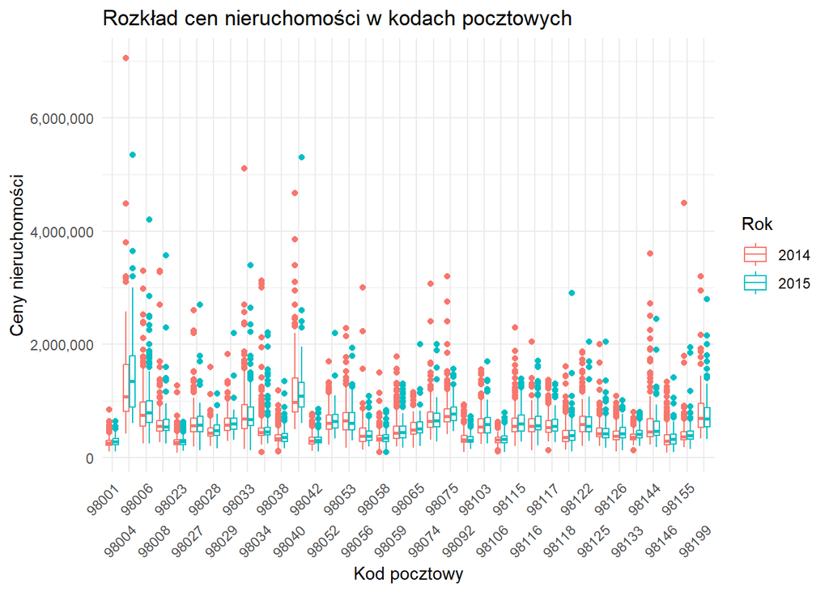

```r
# Tu umieść kod do wygenerowania odpowiedzi do zadania.

df1 <- df %>%
  group_by(zipcode) %>%
  mutate(count=n(), date = as.Date(date, format = "%Y%m%d"), rok = format(date, "%Y")) %>%
  filter(count>280)

ggplot(df1, aes(x = factor(zipcode), y = price)) +
  labs(title = "Rozkład cen nieruchomości w kodach pocztowych",
       x = "Kod pocztowy",
       y = "Ceny nieruchomości",
       color = "Rok") +
  geom_boxplot(aes(color = factor(rok))) +
  scale_y_continuous(labels = function(x) format(x, big.mark = ",", scientific = FALSE)) +
  theme_minimal() +
  scale_x_discrete(guide = guide_axis(n.dodge = 2, angle = 45))
```

## Zadanie 2

Czy jest różnica w rozkładzie ceny nierchomości od powierzchni mieszkalnej uwzględniając podział na nieruchomości z piwnicą i bez?

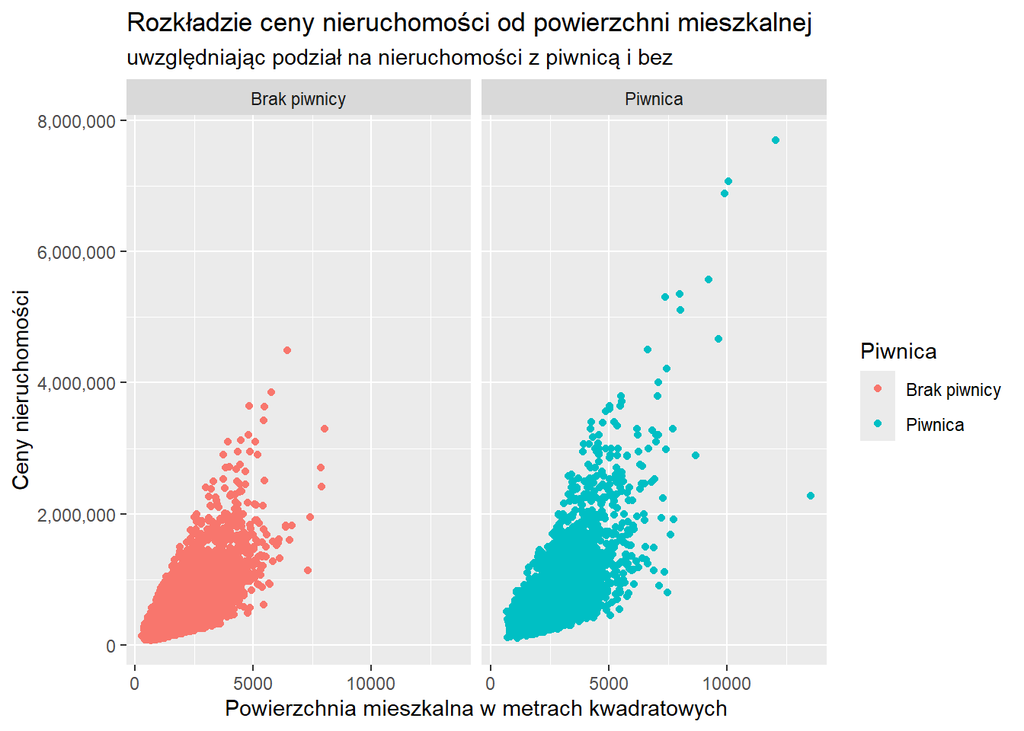

```r
# Tu umieść kod do wygenerowania odpowiedzi do zadania.

df1 <- df %>%
  mutate(Piwnica = ifelse(sqft_basement != 0,"Piwnica","Brak piwnicy"))

ggplot(df1, aes(x = sqft_living, y = price, color = Piwnica)) +
  geom_point() +
  scale_y_continuous(labels = function(x) format(x, big.mark = ",", scientific = FALSE)) +
  labs(title = "Rozkładzie ceny nieruchomości od powierzchni mieszkalnej",
       subtitle = "uwzględniając podział na nieruchomości z piwnicą i bez",
       x = "Powierzchnia mieszkalna w metrach kwadratowych",
       y = "Ceny nieruchomości") +
    facet_wrap(~Piwnica)
```

**Komentarz: Nie ma różnicy prawie w ogóle, poza taką że widać że domy z piwnicą mają więcej powierzchni mieszkalnej (ale to oczywiste) i są droższe (ale to też dosyć oczywiste)**

## Zadanie 3

Jaka jest zależność pomiędzy jakością wykończenia nieruchomości a liczbą pięter?

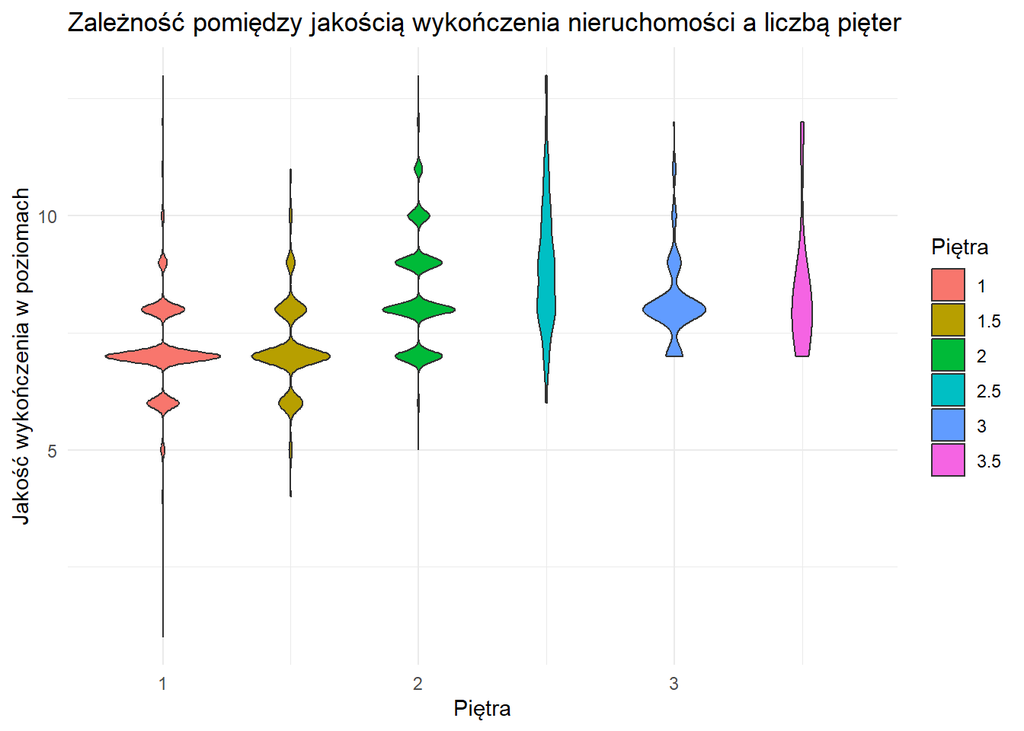

```r
# Tu umieść kod do wygenerowania odpowiedzi do zadania.

ggplot(df, aes(x = floors, y = grade, fill = factor(floors))) +
  geom_violin() +
  labs(title = "Zależność pomiędzy jakością wykończenia nieruchomości a liczbą pięter",
       x = "Piętra",
       y = "Jakość wykończenia w poziomach",
       fill = "Piętra")+
  theme_minimal()
```

**Komentarz: Widać że im więcej pięter tym lepsza jakość wykończenia, ale nie jest to mocna korelacja. jedno piętrowwe i półtora piętrowe domy są bardzo podobne, ale to od dwu piętrowych domów zaczyna się zwiększać jakość. Po dwóch piętrach jest razcej stabilna**

## Zadanie 4

Jaka jest zależność między powierzchnią mieszkalną nieruchomości a powierzchnią gruntu w podziale na liczbę sypialni?

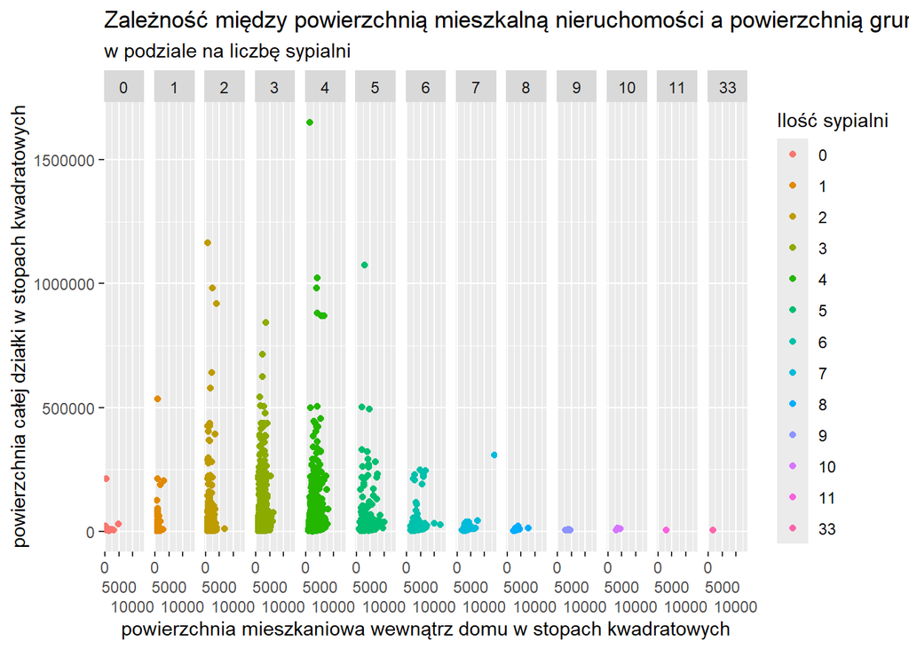

```r
# Tu umieść kod do wygenerowania odpowiedzi do zadania.

ggplot(df, aes(x = sqft_living, y = sqft_lot)) +
  geom_point(aes(color = factor(bedrooms))) +
  facet_grid(~bedrooms) +
  labs(title = "Zależność między powierzchnią mieszkalną nieruchomości a powierzchnią gruntu",
       subtitle = "w podziale na liczbę sypialni",
       x = "powierzchnia mieszkaniowa wewnątrz domu w stopach kwadratowych",
       y = "powierzchnia całej działki w stopach kwadratowych",
       color = "Ilość sypialni") +
  scale_x_continuous(guide = guide_axis(n.dodge = 3))
```

**Komentarz: Powierzchnia mieszkalna w domach 0, 1, 6, 7, 8, 9, 10, 11 i 33 sypialnianych jest mniej więcej jeden do jednego z paroma wyjątkami. DOpiero w 2, 3, 4 i 5 sypialnianych domach powierzchnia wielkość działki strasznie leci w górę i jest nieproporcjonalnie większa od powierzchni wewnętrznej ale to pewnie tylko bogaci ludzie**

## Zadanie 5

Rozważmy tylko nieruchomości, które miały remont. W której dekadzie było najwięcej przeprowadzonych remontów? Czy w poszczególnych dekadach jest porównywalny procent nieruchmości dla każdej wartości miary jakości i wykończenia nieruchomości?

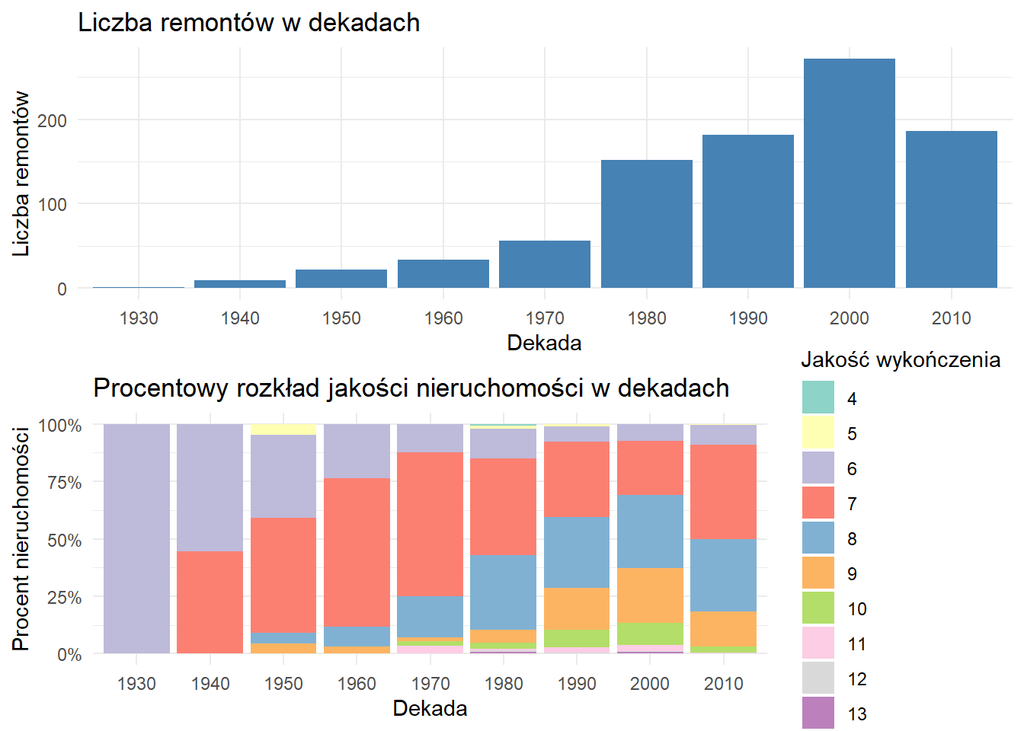

```r
# Tu umieść kod do wygenerowania odpowiedzi do zadania.

df1 <- df %>%
  filter(yr_renovated != 0) %>%
  mutate(date = as.Date(date, format = "%Y%m%d"),
         Dekada = floor(yr_renovated / 10) * 10)

ile_w_dekadzie <- df1 %>%
  group_by(Dekada) %>%
  summarise(count = n(), .groups = 'drop')

jakość <- df1 %>%
  group_by(Dekada, grade) %>%
  summarise(count = n(), .groups = 'drop') %>%
  mutate(percentage = count / sum(count) * 100)

p1 <- ggplot(ile_w_dekadzie, aes(x = factor(Dekada), y = count)) +
  geom_bar(stat = "identity", fill = "steelblue") +
  labs(title = "Liczba remontów w dekadach",
       x = "Dekada",
       y = "Liczba remontów") +
  theme_minimal()

p2 <- ggplot(jakość, aes(x = factor(Dekada), y = percentage, fill = factor(grade))) +
  geom_bar(stat = "identity", position = "fill") +
  labs(title = "Procentowy rozkład jakości nieruchomości w dekadach",
       x = "Dekada",
       y = "Procent nieruchomości",
       fill = "Jakość wykończenia") +
  scale_y_continuous(labels = scales::percent_format(scale = 100)) +
  theme_minimal() +
  scale_fill_brewer(palette = "Set3")

gridExtra::grid.arrange(p1, p2, nrow = 2)
```

## Zadanie 6

Jak prezentuje się wartość minimalna, średnia i maksymalna ceny nieruchmości w podziele na rok budowy nieruchomości.

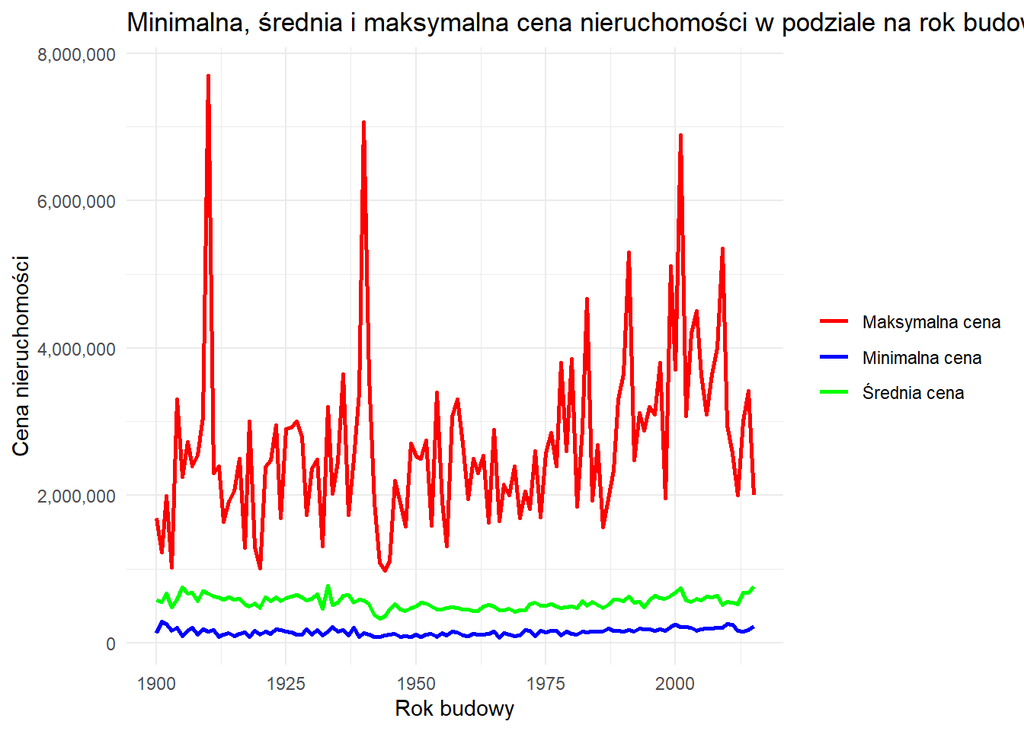

```r
# Tu umieść kod do wygenerowania odpowiedzi do zadania.

df1 <- df %>%
  group_by(yr_built) %>%
  summarize(maksymalna=max(price),
            minimalna=min(price),
            średnia=mean(price))

ggplot(df1, aes(x = yr_built)) +
  geom_line(aes(y = minimalna, color = "Minimalna cena"), size = 1) +
  geom_line(aes(y = średnia, color = "Średnia cena"), size = 1) +
  geom_line(aes(y = maksymalna, color = "Maksymalna cena"), size = 1) +
  labs(title = "Minimalna, średnia i maksymalna cena nieruchomości w podziale na rok budowy",
       x = "Rok budowy",
       y = "Cena nieruchomości") +
  scale_color_manual(values = c("Minimalna cena" = "blue", "Średnia cena" = "green", "Maksymalna cena" = "red")) +
  scale_y_continuous(labels = function(x) format(x, big.mark = ",", scientific = FALSE)) +
  theme_minimal() +
  theme(legend.title = element_blank())
```

**Komentarz: Widać że mimo znacznej różnicy między maksymalną ceną a minimalną ceną to średnia cena wydaje się bardziej przybliżona minimalnej cenie co nam pokazuje że droższych zakupów było znacznie mniej niż tańszych**